# test

Joao Neto

Friday, October 17, 2014

```r
library(BRugs)
```

```r
#------------------------------------------------------------------------------
run.model <- function(model, samples, data=list(), chainLength=10000, burnin=0.10,
                      init.func, n.chains=1, thin=1) {

  writeLines(model, con="model.txt")  # Write the modelString to a file
  modelCheck( "model.txt" )           # Send the model to BUGS, which checks the model syntax
  if (length(data)>0)                 # If there's any data available...
    modelData(bugsData(data))         # ... BRugs puts it into a file and ships it to BUGS
  modelCompile()                      # BRugs command tells BUGS to compile the model

  if (missing(init.func)) {
    modelGenInits()                   # BRugs command tells BUGS to randomly initialize a chain
  } else {
    for (chain in 1:n.chains) {       # otherwise use user's init data
      modelInits(bugsInits(init.func))
    }
  }

  modelUpdate(chainLength*burnin)     # Burn-in period to be discarded
  samplesSet(samples)                 # BRugs tells BUGS to keep a record of the sampled values
  samplesSetThin(thin)                # Set thinning
  modelUpdate(chainLength)            # BRugs command tells BUGS to randomly initialize a chain
}
#------------------------------------------------------------------------------
```

## Mixture of Gaussians

Let’s say we have this dataset (taken from [Bayesian Methods for Hackers](http://camdavidsonpilon.github.io/Probabilistic-Programming-and-Bayesian-Methods-for-Hackers/)):

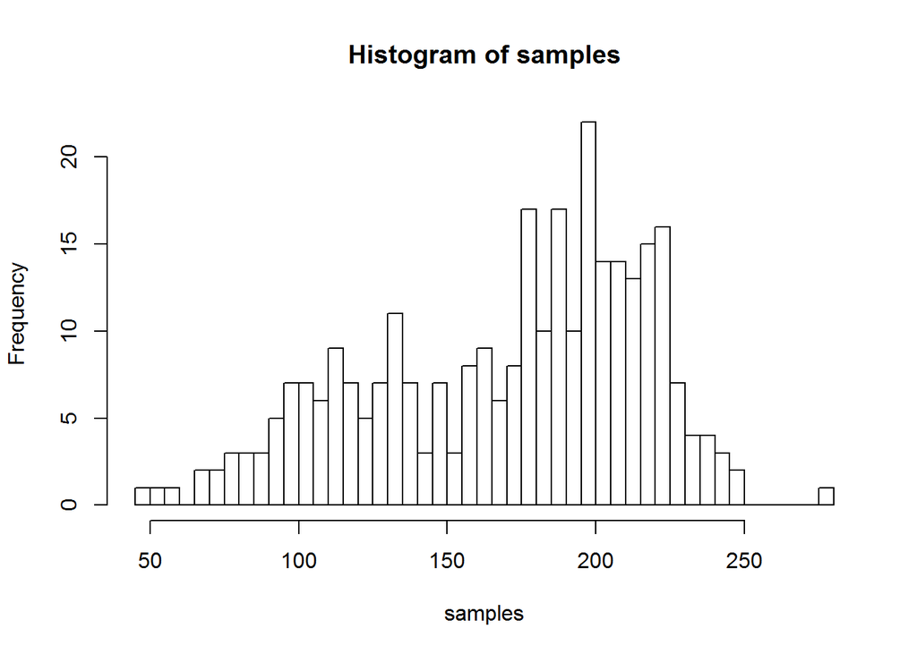

```r
samples <- read.csv("mixture_data.csv", header=F)[,1]
samples <- as.numeric(levels(samples)[samples])  # because it read the values as factors
hist(samples, breaks=40)
```

It appears the data has a bimodal form, one peak around 120 and another at 200.

Our model proposes that the dataset has two clusters of data, each produced by a normal distribution. The construction was:

1. For each data point $y_i$:
2. choose distribution 1 with probability $p$, or distribution 2 with probability $1-p$
3. Draw one random sample from the chosen distribution $\mathcal{N}(\mu_k, \sigma_k)$, $k=1,2$

So, our model is

$G_i \sim \text{Binomial}(p)$

$y_i \sim \mathcal{N}(\mu_{G_i}, \sigma_{G_i})$

$\mu_k \sim \mathcal{N}(0,1000)$

$\sigma_k \sim \text{Gamma}(0.01, 0.01)$

$G_i$ means the cluster of the i-th datapoint; in this problem $G_i = \{1,2\}$. In the following model, it is used `dcat` instead of a binomial, just because this way it can also work with more than two clusters.

```r
modelString = "
# BUGS model specification begins ...

model {

  for( i in 1 : N ) {
     y[i]   ~  dnorm(mu[i], tau[i])  # likelihood
     mu[i]  <- lambda[G[i]]          # prior for mean
     tau[i] <- lambdaTau[G[i]]       # prior for precision
     G[i]   ~  dcat(P[])             # the cluster attributions for each y_i
  }

  P[1:2] ~ ddirch(alpha[])           # dirichlet distribution (in this case just for 2 clusters)
  alpha[1] <- 0.5                    # It generalizes the beta (with K=2 we could have used the beta), and
  alpha[2] <- 0.5                    # is the conjugate for the categorical distribution

  lambda[1] ~ dnorm(0.0, 1.0E-6)     # hyperparameters for mean
  lambda[2] <- lambda[1] + theta
  theta ~ dnorm(0.0, 1.0E-6)I(0.0, )

  lambdaTau[1] ~ dgamma(0.01,0.01)   # hyperparameters for precision/standard deviation
  lambdaTau[2] ~ dgamma(0.01,0.01)

  sigma[1] <- 1 / sqrt(lambdaTau[1])
  sigma[2] <- 1 / sqrt(lambdaTau[2])
}

# ... BUGS model specification ends.
" # close quote to end modelString
```

There is a trick here. To prevent divergence issues (all datapoints selected to a single cluster), the second mean hyperparameter, $\lambda_2$, is determined this way: $\lambda_2 = \lambda_1 + \theta, \theta \gt 0$ (check Bugs Book, pages 280-3).

```r
data.list = list(
  y = samples,
  N = length(samples),
  G = c(1, rep(NA,length(samples)-2), 2)  # TODO: do not understand these 1 and 2
)

# let's apply some thinning to the mcmc:
run.model(modelString, samples=c("sigma", "lambda", "P", "G"), data=data.list, chainLength=3e4, thin=4)
```

```
## model is syntactically correct
## data loaded
## model compiled
## 3000 updates took 2 s
## monitor set for variable 'sigma'
## monitor set for variable 'lambda'
## monitor set for variable 'P'
## monitor set for variable 'G'
## 30000 updates took 30 s
```

```r
samplesStats("sigma")
```

```
##           mean    sd MC_error val2.5pc median val97.5pc start sample
## sigma[1] 31.53 5.310  0.25370    23.59  30.61     44.25  3001   7500
## sigma[2] 22.18 2.204  0.08703    17.61  22.23     26.41  3001   7500
```

```r
samplesStats("lambda")
```

```
##            mean    sd MC_error val2.5pc median val97.5pc start sample
## lambda[1] 122.8 8.485   0.4445    110.4  121.1     144.5  3001   7500
## lambda[2] 200.7 3.047   0.1237    195.0  200.6     206.8  3001   7500
```

```r
samplesStats("P")
```

```
##        mean      sd MC_error val2.5pc median val97.5pc start sample
## P[1] 0.3975 0.07069 0.003455   0.2898  0.386    0.5789  3001   7500
## P[2] 0.6025 0.07069 0.003455   0.4211  0.614    0.7102  3001   7500
```

```r
samplesCorrel("sigma[1]", "sigma[2]") # the correlation is negative: one sd larger means the other is smaller
```

```
##          sigma.2.
## sigma[1]  -0.6214
```

Let’s vizualize the results:

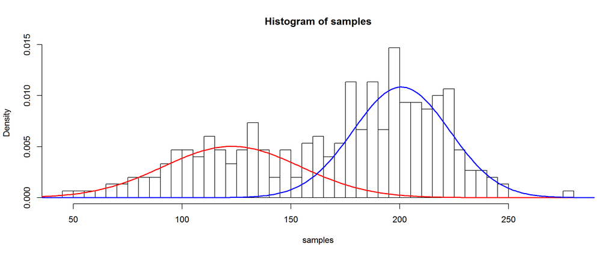

```r
p <- samplesStats("P")$mean[1]
mu1.hat <- samplesStats("lambda")$mean[1]
mu2.hat <- samplesStats("lambda")$mean[2]
sigma1.hat <- samplesStats("sigma")$mean[1]
sigma2.hat <- samplesStats("sigma")$mean[2]

hist(samples, breaks=40, prob=T)
xs <- 0:300
lines(xs,  p  *dnorm(xs,mu1.hat,sigma1.hat), col="red",  lwd=2)
lines(xs,(1-p)*dnorm(xs,mu2.hat,sigma2.hat), col="blue", lwd=2)
```

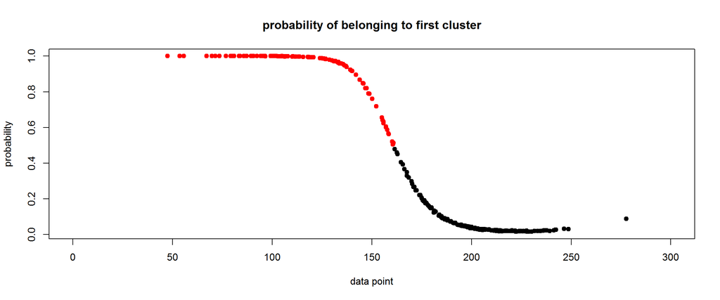

```r
prob.cluster.1 <- 2 - samplesStats("G")[,1]
# need to remove the first and last observations until the previous TODO: is solved
plot(samples[c(-1,-300)], prob.cluster.1, col = 1+round(prob.cluster.1), xlim=c(0,300),
     xlab="data point", ylab="probability", main="probability of belonging to first cluster", pch=19)
```

Let’s also use BRugs graphical tools:

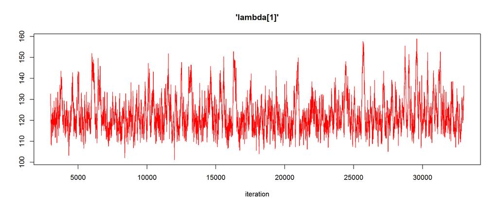

```r
# cannot use samplesHistory("*") because of nodes G[]
samplesHistory("lambda[1]", mfrow = c(1, 1))
```

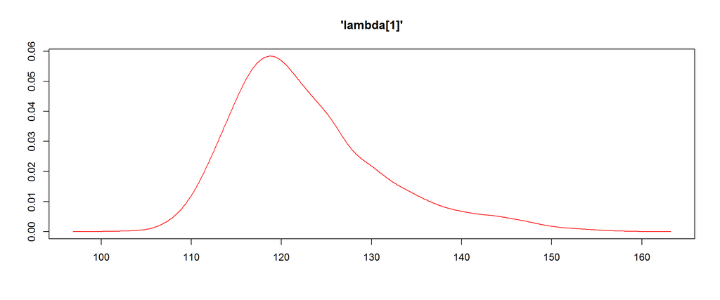

```r
samplesDensity("lambda[1]", mfrow = c(1, 1))
```

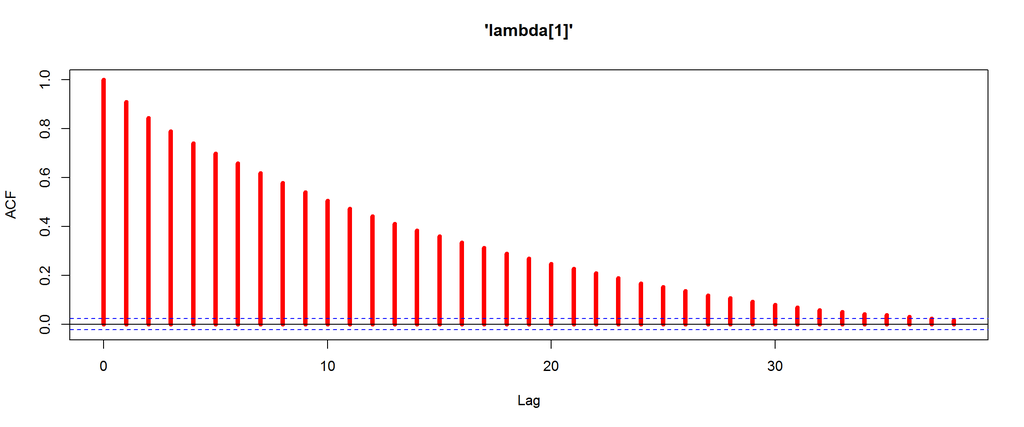

```r
samplesAutoC("lambda[1]", mfrow = c(1, 1), 1)
```